# MEML_HW09

**Machine Learning for Mechanical Engineering**  
**Homework 09**  
**Due Thursday, 06/11/2020, 9:30 AM**

TA: JongHwan Lee  
Instructor: Prof. Seungchul Lee  
http://iai.postech.ac.kr/  
Industrial AI Lab at POSTECH

- For your handwritten solution, scan or take a picture of them.
- For your code, only .ipynb file will be graded.
  - Please write your NAME and student ID on your .ipynb files. ex) LeeJongHwan_HW09.ipynb
- Please compress all files to make a single .zip file
  - Please write your NAME and student ID on your .zip files. ex) LeeJongHwan_HW09.zip
  - Submit it to LMS
- Do not submit a printed version of your code. It will not be graded.

# Problem 1

Download this data [reg_pca_data](https://www.dropbox.com/s/onvx5yebdvb3ct2/x_reg_and_y_reg_reg_pca.zip?dl=1)

```python
from six.moves import cPickle

x_reg = cPickle.load(open('./data_files/x_reg.pkl', 'rb'))
y_reg = cPickle.load(open('./data_files/y_reg.pkl', 'rb'))
```

1) Write a python code to conduct a linear regression (least square).

```python
## your code here
```

2) Write a python code to perform PCA. Since `mean(x) = mean(y) = 0`, normalization step (mean subtraction and rescaling) can be skipped.

```python
## your code here
```

3) Plot both the regression line and the PCA line at the same time.

```python
## your code here
```

# Problem 2

We would like to use the FDA(LDA) to classify digit 0 and digit 1

| Data | Data dexcription |
| --- | --- |
| 0 | 1000 images (28×28 pixels) of handwritten digit 0 |
| 1 | 1000 images (28×28 pixels) of handwritten digit 1 |

[Download data](https://www.dropbox.com/s/aokbzv5cy2rbmzy/data.pkl?dl=1)

To read the files in Python, use the following code:

```python
import matplotlib.pyplot as plt
from six.moves import cPickle
import numpy as np
data = cPickle.load(open('./data_files/data.pkl', 'rb'))
data0 = data['0']
data1 = data['1']
```

1) Convert each of the pixels in 28×28 matrix to a binary value.

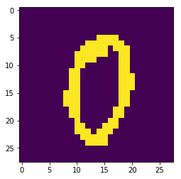

```python
## your code here
```

2) Extract features and plot them in the feature space. Now we select the own ‘features’ from image data to detect digit 0 and digit 1. Two features are recommended

- (feature 1) The total average pixels located at the center of the image (`img[10:20,10:20]`).
- (feature 2) The total average pixels over the entire location.

$$\Phi(x) = \begin{bmatrix}\ \text{feature1}\\ \text{feature2} \end{bmatrix}$$

You should end up with a $2000\times2$ input matrix with the first $1000$ rows correspond to all of the ‘`data0`’ and the second 1000 rows correspond to the two features for all of the given ‘`data1`’.

```python
## your code here
```

```
(2000, 2)
```

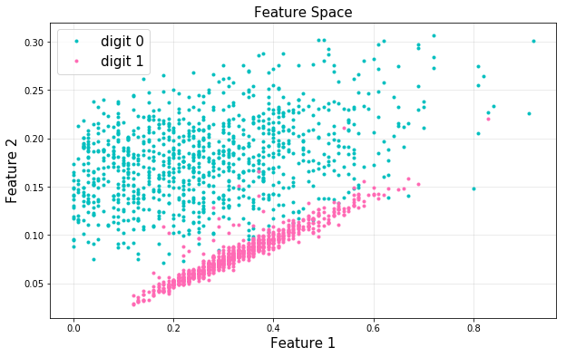

```python
## your code here
```

3) Solve the problem with the FDA (LDA) and visualize the histogram of data on the projection line by class.

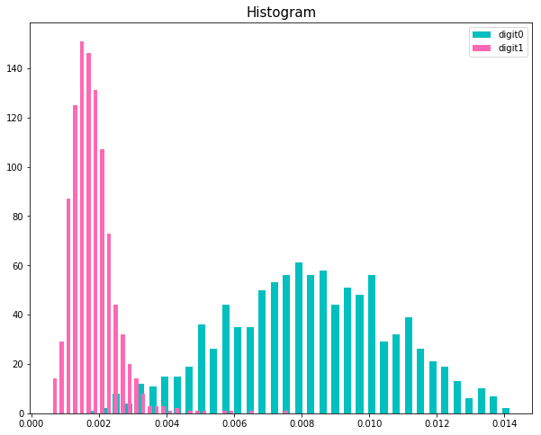

```python
## your code here
```

4) Plot the projection line and the classification boundary in feature space.

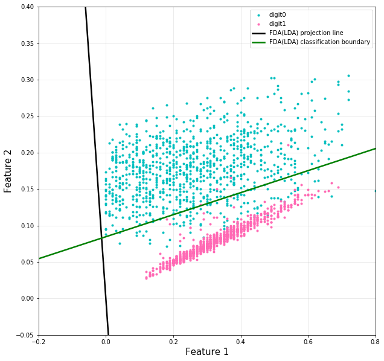

```python
## your code here
```

# Problem 3

Describe the difference between the process of finding the linear regression line and the PCA line.

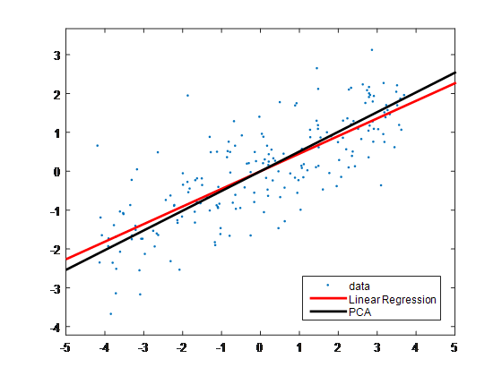